# Model for Human Activity Recognition

## Loading and preprocessing the data

HAR has been considered as a potential technology for e-health systems. So Wallace Ugulino and others collected a public domain dataset comprising 165,633 samples of 5 activity classes, gathered from 4 subjects wearing accelerometers mounted on their waist, left thigh, right arm, and right ankle [1]. Part of data which we're going to use for our model can be found here: https://d396qusza40orc.cloudfront.net/predmachlearn/pml-training.csv. I shall use R language [2] to build prediction model of human activity. My inspection of raw data shows that there are few mistakes in data columns and date information is not in appropriate format. So we must open and prepocess data. In preprocessing I shall use package “caret” [3].

```r
# Open data from the URL and convert mistakes to NAs
data <- read.csv("pml-training.csv", header = T, na.strings = c(NA, "", "#DIV/0!"),
    row.names = "X")

# Hours of activity can play significant role in prediction algorithm.
# Let's convert raw timestamps to hours when data were recorded
mydates = data$raw_timestamp_part_1
class(mydates) = c("POSIXt", "POSIXct")
mydate = as.POSIXlt(mydates)
data$hours <- mydate$hour

# Remove variables with NAs

NAs <- apply(data, 2, function(x) {
    sum(is.na(x))/length(x)
})
data <- data[, NAs < 0.9]

# Remove variables with zero or near zero variance
library(caret)
nsv <- nearZeroVar(data, saveMetrics = T)
data <- data[!nsv$nzv]

# Remove unnecessary timestapms and window number

data <- data[-c(2:5)]
```

Note, that in this task we shall predict actions of same persons so variable “user_name” is useful for our task. If we want to predict actions of another users this variable should be excluded.

## Prediction model building

In this part we're going to use few different algorithms to predict activity class. Then we shall compare theri accuracy and choose the best one. Accuracy will be estimated with cross-validation procedure, i.e. I shall split all training data to training and cross-validation sample. Algorithm will be trained on the first part of data and evaluated on the second part of it. In this part I shall use “kernlab” [4], “caTools” [5] and “randomForest” [6] packages.

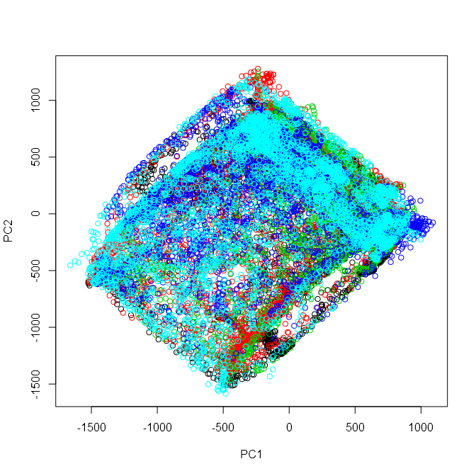

```r
# Randomly split the data, keeping proportions of each class
library(caTools)
set.seed(123)
split = sample.split(data$classe, SplitRatio = 0.8)

# Create training and testing sets
training = subset(data, split == TRUE)
testing = subset(data, split == FALSE)

# We aslo can try to continue data prepocessing. Let's use PCA
prComp <- prcomp(data[, !(names(data) %in% c("classe", "user_name"))])
plot(prComp$x[, 1], prComp$x[, 2], col = data$classe, xlab = "PC1", ylab = "PC2")
```

```r
# The plot shows that data isn't linearly separable, so we can avoid PCA.
# We're trying to predict one of multiple classes so we can use algorithms:
# CART trees, Random Forest and Latent Discriminant Analysis

# Let's train models without data normalization

rpart.mod <- train(classe ~ ., data = training, method = "rpart")
lda.mod <- train(classe ~ ., data = training, method = "lda")
set.seed(123)
rf.mod <- train(classe ~ ., data = training, method = "rf")
# Compare accuracy of models

sum(predict(lda.mod, newdata = testing) == testing$classe)/nrow(testing)
```

```
## [1] 0.7359
```

```r
sum(predict(rpart.mod, newdata = testing) == testing$classe)/nrow(testing)
```

```
## [1] 0.4874
```

```r
sum(predict(rf.mod, newdata = testing) == testing$classe)/nrow(testing)
```

```
## [1] 0.9949
```

```r
# Note, these estimations are not exhaustive. We can use it because there
# are no prices of wrong prediction for each class.  If we know that some
# class is more important than others we should look at confusionMatrix()
# function.
```

As we can see Random Forest algorithm has the best accuracy. The accuracy is estimated on cross-validation sample so we can predict that accuracy out-of-sample will be near 99%.

## Human Activity Prediction

```r
# Model building
rf.mod <- train(classe ~ ., data = training, method = "rf")

# Open and preprocess test data from the URL
test <- read.csv("pml-testing.csv", header = T, na.strings = c(NA, "", "#DIV/0!"),
    row.names = "X")

mydates = test$raw_timestamp_part_1
class(mydates) = c("POSIXt", "POSIXct")
mydate = as.POSIXlt(mydates)
test$hours <- mydate$hour

# Predict human activity with our model
answ <- predict(rf.mod, test)
answ
```

```
##  [1] B A B A A E D B A A B C B A E E A B B B
## Levels: A B C D E
```

```r
# Use this function to save answers to separate files

# pml_write_files = function(x){ n = length(x) for(i in 1:n){ filename =
# paste0('problem_id_',i,'.txt')
# write.table(x[i],file=filename,quote=FALSE,row.names=FALSE,col.names=FALSE)
# } }

# pml_write_files(answ)
```

All 20 cases were predicted correctly. Despite this algorithm can be improved with different techniques such as boosting, averaging and so on. This paper was created with package “knitr” [7] for this task.

## References

1. Ugulino, W.; Cardador, D.; Vega, K.; Velloso, E.; Milidiu, R.; Fuks, H. Wearable Computing: Accelerometers' Data Classification of Body Postures and Movements. Proceedings of 21st Brazilian Symposium on Artificial Intelligence. Advances in Artificial Intelligence - SBIA 2012. In: Lecture Notes in Computer Science. , pp. 52-61. Curitiba, PR: Springer Berlin / Heidelberg, 2012. ISBN 978-3-642-34458-9. DOI: 10.1007/978-3-642-34459-6_6.
2. R Core Team (2014). R: A language and environment for statistical computing. R Foundation for Statistical Computing, Vienna, Austria. URL http://www.R-project.org/.
3. Max Kuhn. Contributions from Jed Wing, Steve Weston, Andre Williams, Chris Keefer, Allan Engelhardt, Tony Cooper, Zachary Mayer and the R Core Team (2014). caret: Classification and Regression Training. R package version 6.0-24. http://CRAN.R-project.org/package=caret
4. Alexandros Karatzoglou, Alex Smola, Kurt Hornik, Achim Zeileis (2004). kernlab - An S4 Package for Kernel Methods in R. Journal of Statistical Software 11(9), 1-20. URL http://www.jstatsoft.org/v11/i09/
5. Jarek Tuszynski (2013). caTools: Tools: moving window statistics, GIF, Base64, ROC AUC, etc.. R package version 1.16. http://CRAN.R-project.org/package=caTools.
6. A. Liaw and M. Wiener (2002). Classification and Regression by randomForest. R News 2(3), 18–22.
7. Yihui Xie (2013). knitr: A general-purpose package for dynamic report generation in R. R package version 1.5.